# MAS2908 - Computer Assessment (Solutions)

Clement Lee

Semester 2, 2025/2026

# 1 Introduction

In this computer assessment you will build a single **Shiny app** containing two interactive visualisations of Northern Ireland census geography data. The content assessed is:

- Downloading a shapefile from an online source and reading it into R using `read_sf()`
- Creating geospatial visualisations with polygon geometry using `geom_sf()`
- Overlaying multiple spatial layers
- Colouring the interior of geographic areas/regions using the `fill` aesthetic
- Using `selectInput` in conjunction with `filter()` from the package `dplyr` to make both visualisations react to a single user input

**Total marks: 10**

# 2 Creating the deliverable

## 2.1 Packages

Ensure the following packages are installed, installing any that are missing:

```r
install.packages(c("shiny", "ggplot2", "dplyr", "sf"))
```

Load them at the top of your `app.R`:

```r
library(shiny)
library(ggplot2)
library(dplyr)
library(sf)
```

## 2.2 Creating `app.R`

In RStudio, go to **File → New File → Shiny Web App**. Set the app name to `computer-assessment` and choose **Single File (app.R)**. RStudio will create a new folder called `computer-assessment/` in your working directory containing `app.R`. All your work for this assessment goes inside that `app.R`.

The two visualisations required by Questions 1 and 2 must both live in this **single app**, sharing the same input control. Place the two plots side by side using `fluidRow()` and `column()` (each `column` with `width = 6`).

# 3 Question 1: Geospatial map (6 marks)

Download the Northern Ireland Super Data Zone (SDZ) boundaries from NISRA at https://www.nisra.gov.uk/publications/super-data-zone-boundaries-gis-format (choose the ESRI Shapefile option). Extract the downloaded zip file directly into your `computer-assessment/` folder, so that the path `computer-assessment/geography-sdz2021-esri-shapefile/SDZ2021.shp` exists.

At the top of `app.R`, **above** the `ui` and `server` definitions, add the following line to load the data once when the app starts:

```r
ni <- read_sf("geography-sdz2021-esri-shapefile/SDZ2021.shp")
```

The object `ni` is a simple feature collection with 850 rows (one per Super Data Zone) and the following columns relevant to this assessment:

| Column | Description |
| --- | --- |
| `SDZ2021_cd` | SDZ code |
| `SDZ2021_nm` | SDZ name |
| `LGD2014_nm` | Local Government District name (11 districts) |
| `Area_ha` | Area in hectares |
| `Perim_km` | Perimeter in kilometres |

Add a `selectInput` to the UI that lets the user choose one of the 11 Local Government Districts from `LGD2014_nm`. Use the unique values of `ni$LGD2014_nm` as the choices.

In the server, create a `renderPlot()` that produces a map with **two layers**:

1. A base layer showing **all 850 Super Data Zones** in grey boundary, using `geom_sf(data = ni)`.
2. A top layer showing only the Super Data Zones belonging to the district selected by the user, with the `fill` aesthetic according to the variable `Perim_km` and the boundaries not shown, meaning that you will have `aes(fill = Perim_km)` and `colour = NA` somewhere in the code.

For reference, if the selected Local Government District is “Belfast”, your map should look like this:

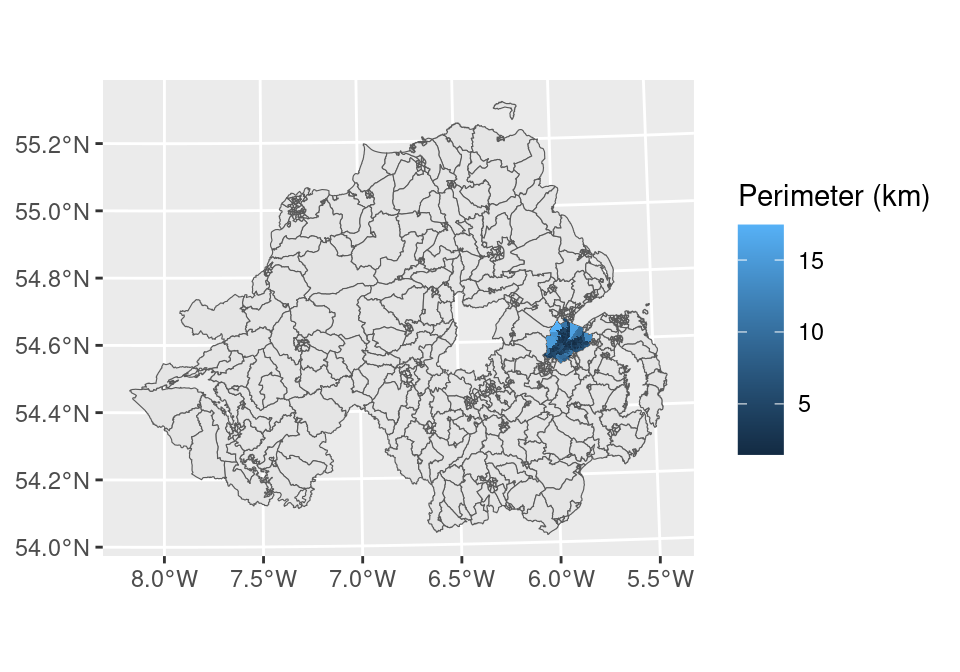

# 4 Question 2: Scatterplot (4 marks)

Using the **same `selectInput`** from Question 1, add a second `renderPlot()` to the server that produces a scatterplot of `Area_ha` (y-axis) against `Perim_km` (x-axis) for the Super Data Zones belonging to the selected Local Government District only.

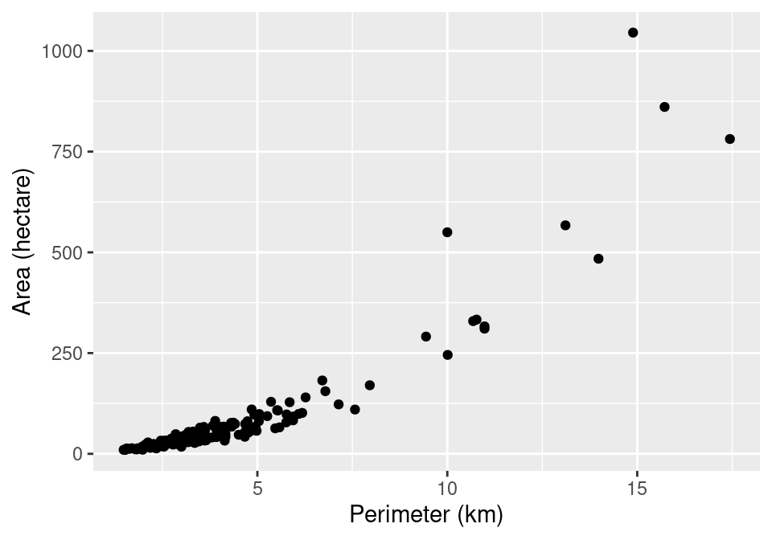

# 5 Question 3: Labels and titles (0 marks)

Add meaningful labels and titles to both plots. Although this question carries no marks, clear labels are expected in professional data visualisation. Use `labs()` to set `x`, `y`, `fill` and `title` for each plot. The title could, for example, display the currently selected district name.